# R Data Wrangling

# Workshop description

Data scientists are known and celebrated for modeling and visually displaying information, but down in the data science engine room there is a lot of less glamorous work to be done. Before data can be used effectively it must often be cleaned, corrected, and reformatted. This workshop introduces the basic tools needed to make your data behave, including data reshaping, regular expressions and other text manipulation tools.

This is an intermediate/advanced R course appropriate for those with basic knowledge of R. If you need a refresher we recommend the [the IQSS R intro](http://tutorials.iq.harvard.edu/R/Rintro/Rintro.html).

The lesson notes are available at [https://dss.iq.harvard.edu](http://tutorials.iq.harvard.edu/R/RDataWrangling/RDataWrangling.html)

# Prerequisites and Preparation

Prior to the workshop you should:

- install R from https://cran.r-project.org/
- install RStudio from https://www.rstudio.com/products/rstudio/download/#download
- install the tidyverse package in R with `install.packages("tidyverse")` and attach it with `library(tidyverse)`

To start the workshop: - Download the 'R Data Wrangling` workshop materials from http://tutorials.iq.harvard.edu/R/RDataWrangling.zip. - Open Rstudio and create a new project (`File ==> New Project ==> Existing Directory` and select the `RDataWrangling` folder you downloaded and extracted earlier. - Open a new R script (`File ==> New File ==> R script`) and save it as `Notes.R`.

# Example project overview

It is common for data to be made available on a website somewhere, either by a government agency, research group, or other organizations and entities. Often the data you want is spread over many files, and retrieving it all one file at a time is tedious and time consuming. Such is the case with the baby names data we will be using today.

The UK [Office for National Statistics](https://www.ons.gov.uk) provides yearly data on the most popular baby names going back to 1996. The data is provided separately for boys and girls and is stored in Excel spreadsheets.

I have downloaded all the excel files containing boys names data from https://www.ons.gov.uk/peoplepopulationandcommunity/birthsdeathsandmarriages/livebirths/datasets/babynamesenglandandwalesbabynamesstatisticsboys and made them available at http://tutorials.iq.harvard.edu/R/RDataWrangling/data/boysNames.zip.

Our mission is to extract and graph the **top 100** boys names in England and Wales for every year since 1996. There are several things that make this challenging.

# Problems with the data

While it was good of the UK Office for National Statistics to provide baby name data, they were not very diligent about arranging it in a convenient or consistent format.

## Exercise 0

Our mission is to extract and graph the **top 100** boys names in England and Wales for every year since 1996. There are several things that make this challenging.

1. Locate the file named `1996boys_tcm77-254026.xlsx` and open it in a spreadsheet. (If you don’t have a spreadsheet program installed on your computer you can downloads one from https://www.libreoffice.org/download/download/). What issues can you identify that might make working with these data more difficult?
2. Locate the file named `2015boysnamesfinal.xlsx` and open it in a spreadsheet. In what ways is the format different than the format of `1996boys_tcm77-254026.xlsx`? How might these differences make it more difficult to work with these data?

## Exercise 0 Prototype

> 1. Locate the file named `1996boys_tcm77-254026.xlsx` and open it in a spreadsheet. (If you don’t have a spreadsheet program installed on your computer you can downloads one from https://www.libreoffice.org/download/download/). What issues can you identify that might make working with these data more difficult?

The data does not start on row one. Headers are on row 7, followed by a blank line, followed by the actual data.

The data is stored in an inconvenient way, with ranks 1-50 in the first set of columns and ranks 51-100 in a separate set of columns.

There are notes below the data.

> 3. Locate the file named `2015boysnamesfinal.xlsx` and open it in a spreadsheet. In what ways is the format different than the format of `1996boys_tcm77-254026.xlsx`? How might these differences make it more difficult to work with these data?

The worksheet containing the data of interest is in different positions and has different names from one year to the next. However, it always includes “Table 1” in the worksheet name.

Some years include columns for “changes in rank”, others do not.

These differences will make it more difficult to automate re-arranging the data since we have to write code that can handle different input formats.

# Useful data manipulation packages

As you can see, the data is in quite a messy state. Note that this is not a contrived example; this is exactly the way the data came to us from the UK government website! Let’s start cleaning and organizing it. The `tidyverse` suite of packages provides many modern conveniences that will make this job easier.

```r
library(tidyverse)
```

# Working with Excel worksheets

Each Excel file contains a worksheet with the baby names data we want. Each file also contains additional supplemental worksheets that we are not currently interested in. As noted above, the worksheet of interest differs from year to year, but always has “Table 1” in the sheet name.

The first step is to get a vector of file names.

```r
boy.file.names <- list.files("data/boys", full.names = TRUE)
```

Now that we’ve told R the names of the data files we can start working with them. For example, the first file is

```r
boy.file.names[[1]]
```

```
## [1] "data/boys/1996boys_tcm77-254026.xlsx"
```

and we can use the `excel_sheets` function from the *readxl* package to list the worksheet names from this file.

```r
library(readxl)

excel_sheets(boy.file.names[[1]])
```

```
## [1] "Contents"                     "Table 1 - Top 100 boys, E&W"
## [3] "Table 2-Top 10 boys by month" "Table 3 - Boys names - E&W"
```

## Iterating over file names with `map`

Now that we know how to retrieve the names of the worksheets in an Excel file we could start writing code to extract the sheet names from each file, e.g.,

```r
excel_sheets(boy.file.names[[1]])
```

```
## [1] "Contents"                     "Table 1 - Top 100 boys, E&W"
## [3] "Table 2-Top 10 boys by month" "Table 3 - Boys names - E&W"
```

```r
excel_sheets(boy.file.names[[2]])
```

```
## [1] "Contents"                        "Table 1 - Top 100 boys, E&W"
## [3] "Table 2 - Top 100 boys, England" "Table 3 - Top 100 boys, Wales"
## [5] "Table 4 - Top 10 boys by region" "Table 5 - Top 10 boys by month"
## [7] "Table 6 - Boys names - E&W"
```

```r
## ...
excel_sheets(boy.file.names[[20]])
```

```
##  [1] "Contents"             "Metadata"             "Terms and Conditions"
##  [4] "Table 1"              "Table 2"              "Table 3"
##  [7] "Table 4"              "Table 5"              "Table 6"
## [10] "Related Publications"
```

This is not a terrible idea for a small number of files, but it is more convenient to let R do the iteration for us. We could use a `for` loop, or `sapply`, but the `map` family of functions from the *purrr* package gives us a more consistent alternative, so we’ll use that.

```r
library(purrr)
map(boy.file.names, excel_sheets)
```

```
## [[1]]
## [1] "Contents"                     "Table 1 - Top 100 boys, E&W"
## [3] "Table 2-Top 10 boys by month" "Table 3 - Boys names - E&W"
##
## [[2]]
## [1] "Contents"                        "Table 1 - Top 100 boys, E&W"
## [3] "Table 2 - Top 100 boys, England" "Table 3 - Top 100 boys, Wales"
## [5] "Table 4 - Top 10 boys by region" "Table 5 - Top 10 boys by month"
## [7] "Table 6 - Boys names - E&W"
##
## [[3]]
## [1] "Contents"                        "Table 1 - Top 100 boys' names"
## [3] "Table 2 - Top 100 boys, England" "Table 3 - Top 100 boys, Wales"
## [5] "Table 4 - Top 10 boys by region" "Table 5 - Top 10 boys by month"
## [7] "Table 6 - Boys names - E&W"
##
## [[4]]
## [1] "Contents"                        "Table 1 - Top 100 boys' names"
## [3] "Table 2 - Top 100 boys, England" "Table 3 - Top 100 boys, Wales"
## [5] "Table 4 - Top 10 boys by region" "Table 5 - Top 10 boys by month"
## [7] "Table 6 - Boys names - E&W"
##
## [[5]]
## [1] "Contents"                        "Table 1 - Top 100 boys, E&W"
## [3] "Table 2 - Top 100 boys, England" "Table 3 - Top 100 boys, Wales"
## [5] "Table 4 - Top 10 boys by region" "Table 5 - Top 10 boys by month"
## [7] "Table 6 - Boys names - E&W"
##
## [[6]]
## [1] "Contents"                        "Table 1 - Top 100 boys, E&W"
## [3] "Table 2 - Top 100 boys, England" "Table 3 - Top 100 boys, Wales"
## [5] "Table 4 - Top 10 boys by region" "Table 5 - Top 10 boys by month"
## [7] "Table 6 - Boys names - E&W"
##
## [[7]]
## [1] "Contents"                        "Table 1 - Top 100 boys, E&W"
## [3] "Table 2 - Top 100 boys, England" "Table 3 - Top 100 boys, Wales"
## [5] "Table 4 - Top 10 boys by region" "Table 5 - Top 10 boys by month"
## [7] "Table 6 - Boys names - E&W"
##
```

[output cut: 66 more lines]

```
##  [7] "Table 4 - Top 10 boys by region" "Table 5 - Top 10 boys by month"
##  [9] "Table 6 - Boys names - E&W"      "Related Publications"
##
## [[19]]
##  [1] "Contents"                        "Metadata"
##  [3] "Terms and Conditions"            "Table 1 - Top 100 boys, E&W"
##  [5] "Table 2 - Top 100 boys, England" "Table 3 - Top 100 boys, Wales"
##  [7] "Table 4 - Top 10 boys by region" "Table 5 - Top 10 boys by month"
##  [9] "Table 6 - Boys names - E&W"      "Related Publications"
##
## [[20]]
##  [1] "Contents"             "Metadata"             "Terms and Conditions"
##  [4] "Table 1"              "Table 2"              "Table 3"
##  [7] "Table 4"              "Table 5"              "Table 6"
## [10] "Related Publications"
```

## Filtering strings using regular expressions

In order extract the correct worksheet names we need a way to extract strings containing “Table 1”. Base R provides some string manipulation capabilities (see `?regex`, `?sub` and `?grep`), but we will use the *stringr* package because it is more user-friendly.

The *stringr* package provides functions to *detect*, *locate*, *extract*, *match*, *replace*, *combine* and *split* strings (among other things).

Here we want to detect the pattern “Table 1”, and only return elements with this pattern. We can do that using the `str_subset` function. The first argument to `str_subset` is character vector we want to search in. The second argument is a *regular expression* matching the pattern we want to retain.

If you are not familiar with regular expressions, http://www.regexr.com/ is a good place to start.

Now that we know how to filter character vectors using `str_subset` we can identify the correct sheet in a particular Excel file. For example,

```r
library(stringr)
str_subset(excel_sheets(boy.file.names[[1]]), "Table 1")
```

```
## [1] "Table 1 - Top 100 boys, E&W"
```

## Writing your own functions

The `map*` functions are useful when you want to apply a function to a list or vector of inputs and obtain the return values. This is very convenient when a function already exists that does exactly what you want. In the examples above we mapped the `excel_sheets` function to the elements of a vector containing file names. But now there is no function that both retrieves worksheet names and subsets them. Fortunately, writing functions in R is easy.

```r
get.data.sheet.name <- function(file, pattern) {
    str_subset(excel_sheets(file), pattern)
}
```

Now we can map this new function over our vector of file names.

```r
map(boy.file.names,
    get.data.sheet.name,
    pattern = "Table 1")
```

```
## [[1]]
## [1] "Table 1 - Top 100 boys, E&W"
##
## [[2]]
## [1] "Table 1 - Top 100 boys, E&W"
##
## [[3]]
## [1] "Table 1 - Top 100 boys' names"
##
## [[4]]
## [1] "Table 1 - Top 100 boys' names"
##
## [[5]]
## [1] "Table 1 - Top 100 boys, E&W"
##
## [[6]]
## [1] "Table 1 - Top 100 boys, E&W"
##
## [[7]]
## [1] "Table 1 - Top 100 boys, E&W"
##
## [[8]]
## [1] "Table 1 - Top 100 boys, E&W"
##
## [[9]]
## [1] "Table 1 - Top 100 boys, E&W"
##
## [[10]]
## [1] "Table 1 - Top 100 boys, E&W"
##
## [[11]]
## [1] "Table 1 - Top 100 boys, E&W"
##
## [[12]]
## [1] "Table 1 - Top 100 boys, E&W"
##
## [[13]]
## [1] "Table 1 - Top 100 boys' names"
##
## [[14]]
## [1] "Table 1 - Top 100 boys' names"
##
## [[15]]
## [1] "Table 1 - Top 100 boys, E&W"
##
## [[16]]
## [1] "Table 1 - Top 100 boys, E&W"
##
## [[17]]
## [1] "Table 1 - Top 100 boys, E&W"
##
## [[18]]
## [1] "Table 1 - Top 100 boys, E&W"
##
## [[19]]
## [1] "Table 1 - Top 100 boys, E&W"
##
## [[20]]
## [1] "Table 1"
```

# Reading Excel data files

Now that we know the correct worksheet from each file we can actually read those data into R. We can do that using the `read_excel` function.

We’ll start by reading the data from the first file, just to check that it works. Recall that the actual data starts on row 7, so we want to skip the first 6 rows.

```r
tmp <- read_excel(
    boy.file.names[1],
    sheet = get.data.sheet.name(boy.file.names[1],
                                pattern = "Table 1"),
    skip = 6)

library(dplyr, quietly=TRUE)
glimpse(tmp)
```

```
## Observations: 59
## Variables: 7
## $ X__1     <chr> NA, "1", "2", "3", "4", "5", "6", "7", "8", "9", "10"...
## $ Name     <chr> NA, "JACK", "DANIEL", "THOMAS", "JAMES", "JOSHUA", "M...
## $ Count    <dbl> NA, 10779, 10338, 9603, 9385, 7887, 7426, 6496, 6193,...
## $ X__2     <lgl> NA, NA, NA, NA, NA, NA, NA, NA, NA, NA, NA, NA, NA, N...
## $ X__3     <dbl> NA, 51, 52, 53, 54, 55, 56, 57, 58, 59, 60, 61, 62, 6...
## $ Name__1  <chr> NA, "DOMINIC", "NICHOLAS", "BRANDON", "RHYS", "MARK",...
## $ Count__1 <dbl> NA, 1519, 1385, 1337, 1259, 1222, 1192, 1186, 1135, 1...
```

## Exercise 1

1. Write a function that takes a file name as an argument and reads the worksheet containing “Table 1” from that file. Don’t forget to skip the first 6 rows.
2. Test your function by using it to read *one* of the boys names Excel files.
3. Use the `map` function to read data from all the Excel files, using the function you wrote in step 1.

## Exercise 1 solution

```r
  ## 1. Write a function that takes a file name as an argument and reads
  ##    the worksheet containing "Table 1" from that file.
  read.baby.names <- function(file) {
      sheet.name <- str_subset(excel_sheets(file), "Table 1")
      read_excel(file, sheet = sheet.name, skip = 6)
  }

  ## 2. Test your function by using it to read *one* of the boys names
  ##    Excel files.
  glimpse(read.baby.names(boy.file.names[1]))
```

```
## Observations: 59
## Variables: 7
## $ X__1     <chr> NA, "1", "2", "3", "4", "5", "6", "7", "8", "9", "10"...
## $ Name     <chr> NA, "JACK", "DANIEL", "THOMAS", "JAMES", "JOSHUA", "M...
## $ Count    <dbl> NA, 10779, 10338, 9603, 9385, 7887, 7426, 6496, 6193,...
## $ X__2     <lgl> NA, NA, NA, NA, NA, NA, NA, NA, NA, NA, NA, NA, NA, N...
## $ X__3     <dbl> NA, 51, 52, 53, 54, 55, 56, 57, 58, 59, 60, 61, 62, 6...
## $ Name__1  <chr> NA, "DOMINIC", "NICHOLAS", "BRANDON", "RHYS", "MARK",...
## $ Count__1 <dbl> NA, 1519, 1385, 1337, 1259, 1222, 1192, 1186, 1135, 1...
```

```r
  ## 3. Use the `map` function to read data from all the Excel files,
  ##    using the function you wrote in step 1.
  boysNames <- map(boy.file.names, read.baby.names)
```

# Data cleanup

Now that we’ve read in the data we still have some cleanup to do. Specifically, we need to:

1. fix column names
2. get rid of blank row and the top and the notes at the bottom
3. get rid of extraneous “changes in rank” columns if they exist
4. transform the side-by-side tables layout to a single table.

In short, we want to go from this:

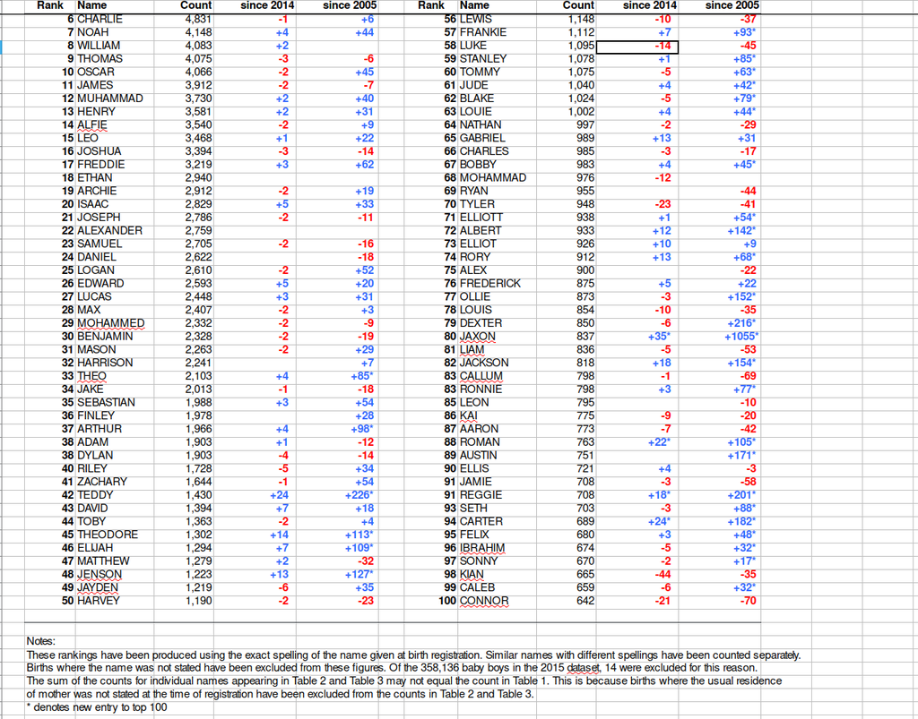

messy

to this:

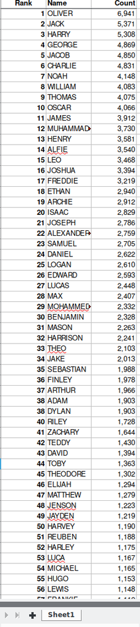

tidy

There are many ways to do this kind of data manipulation in R. We’re going to use the *dplyr* and *tidyr* packages to make our lives easier. (Both packages were installed as dependencies of the *tidyverse* package.)

## Selecting columns

Next we want to retain just the `Name`, `Name__1` and `Count`, `Count__1` columns. We can do that using the `select` function:

```r
boysNames[[1]]
```

```
## # A tibble: 59 x 7
##    X__1  Name    Count X__2   X__3 Name__1  Count__1
##    <chr> <chr>   <dbl> <lgl> <dbl> <chr>       <dbl>
##  1 <NA>  <NA>       NA NA       NA <NA>           NA
##  2 1     JACK    10779 NA       51 DOMINIC      1519
##  3 2     DANIEL  10338 NA       52 NICHOLAS     1385
##  4 3     THOMAS   9603 NA       53 BRANDON      1337
##  5 4     JAMES    9385 NA       54 RHYS         1259
##  6 5     JOSHUA   7887 NA       55 MARK         1222
##  7 6     MATTHEW  7426 NA       56 MAX          1192
##  8 7     RYAN     6496 NA       57 DYLAN        1186
##  9 8     JOSEPH   6193 NA       58 HENRY        1135
## 10 9     SAMUEL   6161 NA       59 PETER        1128
## # ... with 49 more rows
```

```r
boysNames[[1]] <- select(boysNames[[1]], Name, Name__1, Count, Count__1)
boysNames[[1]]
```

```
## # A tibble: 59 x 4
##    Name    Name__1  Count Count__1
##    <chr>   <chr>    <dbl>    <dbl>
##  1 <NA>    <NA>        NA       NA
##  2 JACK    DOMINIC  10779     1519
##  3 DANIEL  NICHOLAS 10338     1385
##  4 THOMAS  BRANDON   9603     1337
##  5 JAMES   RHYS      9385     1259
##  6 JOSHUA  MARK      7887     1222
##  7 MATTHEW MAX       7426     1192
##  8 RYAN    DYLAN     6496     1186
##  9 JOSEPH  HENRY     6193     1135
## 10 SAMUEL  PETER     6161     1128
## # ... with 49 more rows
```

## Dropping missing values

Next we want to remove blank rows and rows used for notes. An easy way to do that is to use `drop_na` to remove rows with missing values.

```r
boysNames[[1]]
```

```
## # A tibble: 59 x 4
##    Name    Name__1  Count Count__1
##    <chr>   <chr>    <dbl>    <dbl>
##  1 <NA>    <NA>        NA       NA
##  2 JACK    DOMINIC  10779     1519
##  3 DANIEL  NICHOLAS 10338     1385
##  4 THOMAS  BRANDON   9603     1337
##  5 JAMES   RHYS      9385     1259
##  6 JOSHUA  MARK      7887     1222
##  7 MATTHEW MAX       7426     1192
##  8 RYAN    DYLAN     6496     1186
##  9 JOSEPH  HENRY     6193     1135
## 10 SAMUEL  PETER     6161     1128
## # ... with 49 more rows
```

```r
boysNames[[1]] <- drop_na(boysNames[[1]])
boysNames[[1]]
```

```
## # A tibble: 50 x 4
##    Name    Name__1  Count Count__1
##    <chr>   <chr>    <dbl>    <dbl>
##  1 JACK    DOMINIC  10779     1519
##  2 DANIEL  NICHOLAS 10338     1385
##  3 THOMAS  BRANDON   9603     1337
##  4 JAMES   RHYS      9385     1259
##  5 JOSHUA  MARK      7887     1222
##  6 MATTHEW MAX       7426     1192
##  7 RYAN    DYLAN     6496     1186
##  8 JOSEPH  HENRY     6193     1135
##  9 SAMUEL  PETER     6161     1128
## 10 LIAM    STEPHEN   5802     1122
## # ... with 40 more rows
```

## Exercise 2

1. Write a function that takes a `data.frame` as an argument and returns a modified version including only columns named `Name`, `Name__1`, `Count`, or `Count__1`.
2. Test your function on the first `data.frame` in the list of baby names data.
3. Use the `map` function to each `data.frame` in the list of baby names data.

## Exercise 2 prototype

```r
  ## 1. Write a function that takes a `data.frame` as an argument and
  ##    returns a modified version including only columns named `Name`,
  ##    `Name__1`, `Count`, or `Count__1`.

  namecount <- function(data) {
      select(data, Name, Name__1, Count, Count__1)
  }

  ## 2. Test your function on the first `data.frame` in the list of baby
  ##    names data.

  namecount(boysNames[[1]])
```

```
## # A tibble: 50 x 4
##    Name    Name__1  Count Count__1
##    <chr>   <chr>    <dbl>    <dbl>
##  1 JACK    DOMINIC  10779     1519
##  2 DANIEL  NICHOLAS 10338     1385
##  3 THOMAS  BRANDON   9603     1337
##  4 JAMES   RHYS      9385     1259
##  5 JOSHUA  MARK      7887     1222
##  6 MATTHEW MAX       7426     1192
##  7 RYAN    DYLAN     6496     1186
##  8 JOSEPH  HENRY     6193     1135
##  9 SAMUEL  PETER     6161     1128
## 10 LIAM    STEPHEN   5802     1122
## # ... with 40 more rows
```

```r
  ## 3. Use the `map` function to each `data.frame` in the list of baby
  ##    names data.

  babyNames <- map(boysNames, namecount)
```

## Re-arranging into a single table

Our final task is to re-arrange to data so that it is all in a single table instead of in two side-by-side tables. For many similar tasks the `gather` function in the *tidyr* package is useful, but in this case we will be better off using a combination of `select` and `bind_rows`.

```r
boysNames[[1]]
```

```
## # A tibble: 50 x 4
##    Name    Name__1  Count Count__1
##    <chr>   <chr>    <dbl>    <dbl>
##  1 JACK    DOMINIC  10779     1519
##  2 DANIEL  NICHOLAS 10338     1385
##  3 THOMAS  BRANDON   9603     1337
##  4 JAMES   RHYS      9385     1259
##  5 JOSHUA  MARK      7887     1222
##  6 MATTHEW MAX       7426     1192
##  7 RYAN    DYLAN     6496     1186
##  8 JOSEPH  HENRY     6193     1135
##  9 SAMUEL  PETER     6161     1128
## 10 LIAM    STEPHEN   5802     1122
## # ... with 40 more rows
```

```r
bind_rows(select(boysNames[[1]], Name, Count),
          select(boysNames[[1]], Name = Name__1, Count = Count__1))
```

```
## # A tibble: 100 x 2
##    Name    Count
##    <chr>   <dbl>
##  1 JACK    10779
##  2 DANIEL  10338
##  3 THOMAS   9603
##  4 JAMES    9385
##  5 JOSHUA   7887
##  6 MATTHEW  7426
##  7 RYAN     6496
##  8 JOSEPH   6193
##  9 SAMUEL   6161
## 10 LIAM     5802
## # ... with 90 more rows
```

## Exercise 3: Cleanup all the data

Your task now is to use the `map` function to apply each of these transformations to all the elements in `boysNames`.

## Exercise prototype

There are different ways you can go about it. Here is one:

```r
## write a function that does all the cleanup
cleanupNamesData <- function(x) {
    filtered <- filter(x, !is.na(Name)) # drop rows with no Name value
    selected <- select(filtered, Name, Count, Name__1, Count__1) # select just Name and Count columns
    bind_rows(select(selected, Name,  Count), # re-arrange into two columns
              select(selected, Name = Name__1, Count = Count__1))
}

## test it out on the second data.frame in the list
glimpse(boysNames[[2]]) # before cleanup
```

```
## Observations: 61
## Variables: 9
## $ X__1            <chr> NA, "1", "2", "3", "4", "5", "6", "7", "8", "9...
## $ Name            <chr> NA, "JACK", "JAMES", "THOMAS", "DANIEL", "JOSH...
## $ Count           <dbl> NA, 10145, 9853, 9479, 9047, 7698, 7443, 6367,...
## $ `since 1996`    <chr> NA, "-", "+2", "-", "-2", "-", "-", "+2", "-",...
## $ X__2            <lgl> NA, NA, NA, NA, NA, NA, NA, NA, NA, NA, NA, NA...
## $ X__3            <dbl> NA, 51, 52, 53, 54, 55, 56, 57, 58, 59, 60, 61...
## $ Name__1         <chr> NA, "SEAN", "DYLAN", "DOMINIC", "LOUIS", "RHYS...
## $ Count__1        <dbl> NA, 1388, 1380, 1359, 1325, 1291, 1274, 1244, ...
## $ `since 1996__1` <chr> NA, "-2", "+5", "-2", "+7", "-1", "-4", "-1", ...
```

```r
glimpse(cleanupNamesData(boysNames[[2]])) # after cleanup
```

```
## Observations: 100
## Variables: 2
## $ Name  <chr> "JACK", "JAMES", "THOMAS", "DANIEL", "JOSHUA", "MATTHEW"...
## $ Count <dbl> 10145, 9853, 9479, 9047, 7698, 7443, 6367, 5809, 5631, 5...
```

```r
## apply the cleanup function to all the data.frames in the list
boysNames <- map(boysNames, cleanupNamesData)
```

# Data organization and storage

Now that we have the data cleaned up and augmented, we can turn our attention to organizing and storing the data.

## One table for each year

Right now we have a list of tables, one for each year. This is not a bad way to go. It has the advantage of making it easy to work with individual years; it has the disadvantage of making it more difficult to examine questions that require data from multiple years. To make the arrangement of the data clearer it helps to name each element of the list with the year it corresponds too.

```r
glimpse(head(boysNames))
```

```
## List of 6
##  $ :Classes 'tbl_df', 'tbl' and 'data.frame':    100 obs. of  2 variables:
##   ..$ Name : chr [1:100] "JACK" "DANIEL" "THOMAS" "JAMES" ...
##   ..$ Count: num [1:100] 10779 10338 9603 9385 7887 ...
##  $ :Classes 'tbl_df', 'tbl' and 'data.frame':    100 obs. of  2 variables:
##   ..$ Name : chr [1:100] "JACK" "JAMES" "THOMAS" "DANIEL" ...
##   ..$ Count: num [1:100] 10145 9853 9479 9047 7698 ...
##  $ :Classes 'tbl_df', 'tbl' and 'data.frame':    100 obs. of  2 variables:
##   ..$ Name : chr [1:100] "JACK" "THOMAS" "JAMES" "DANIEL" ...
##   ..$ Count: num [1:100] 9845 9468 9197 7732 7672 ...
##  $ :Classes 'tbl_df', 'tbl' and 'data.frame':    100 obs. of  2 variables:
##   ..$ Name : chr [1:100] "JACK" "THOMAS" "JAMES" "JOSHUA" ...
##   ..$ Count: num [1:100] 9785 9454 8748 7275 6935 ...
##  $ :Classes 'tbl_df', 'tbl' and 'data.frame':    100 obs. of  2 variables:
##   ..$ Name : chr [1:100] "JACK" "THOMAS" "JAMES" "JOSHUA" ...
##   ..$ Count: num [1:100] 9079 8672 7489 7097 6229 ...
##  $ :Classes 'tbl_df', 'tbl' and 'data.frame':    100 obs. of  2 variables:
##   ..$ Name : chr [1:100] "JACK" "THOMAS" "JOSHUA" "JAMES" ...
##   ..$ Count: num [1:100] 9000 8337 7182 7026 5759 ...
```

```r
years <- str_extract(boy.file.names, "[0-9]{4}")
boysNames <- setNames(boysNames, years)
glimpse(head(boysNames))
```

```
## List of 6
##  $ 1996:Classes 'tbl_df', 'tbl' and 'data.frame':    100 obs. of  2 variables:
##   ..$ Name : chr [1:100] "JACK" "DANIEL" "THOMAS" "JAMES" ...
##   ..$ Count: num [1:100] 10779 10338 9603 9385 7887 ...
##  $ 1997:Classes 'tbl_df', 'tbl' and 'data.frame':    100 obs. of  2 variables:
##   ..$ Name : chr [1:100] "JACK" "JAMES" "THOMAS" "DANIEL" ...
##   ..$ Count: num [1:100] 10145 9853 9479 9047 7698 ...
##  $ 1998:Classes 'tbl_df', 'tbl' and 'data.frame':    100 obs. of  2 variables:
##   ..$ Name : chr [1:100] "JACK" "THOMAS" "JAMES" "DANIEL" ...
##   ..$ Count: num [1:100] 9845 9468 9197 7732 7672 ...
##  $ 1999:Classes 'tbl_df', 'tbl' and 'data.frame':    100 obs. of  2 variables:
##   ..$ Name : chr [1:100] "JACK" "THOMAS" "JAMES" "JOSHUA" ...
##   ..$ Count: num [1:100] 9785 9454 8748 7275 6935 ...
##  $ 2000:Classes 'tbl_df', 'tbl' and 'data.frame':    100 obs. of  2 variables:
##   ..$ Name : chr [1:100] "JACK" "THOMAS" "JAMES" "JOSHUA" ...
##   ..$ Count: num [1:100] 9079 8672 7489 7097 6229 ...
##  $ 2001:Classes 'tbl_df', 'tbl' and 'data.frame':    100 obs. of  2 variables:
##   ..$ Name : chr [1:100] "JACK" "THOMAS" "JOSHUA" "JAMES" ...
##   ..$ Count: num [1:100] 9000 8337 7182 7026 5759 ...
```

## One big table

While storing the data in separate tables by year makes some sense, many operations will be easier if the data is simply stored in one big table. We’ve already seen how to turn a list of data.frames into a single data.frame using `bind_rows`, but there is a problem; The year information is stored in the names of the list elements, and so flattening the tables into one will result in losing the year information! Fortunately it is not too much trouble to add the year information to each table before flattening.

```r
boysNames <- imap(boysNames,
                  function(data, name) {
                      mutate(data, Year = as.integer(name))
                      })
boysNames <- bind_rows(boysNames)

glimpse(boysNames)
```

```
## Observations: 2,000
## Variables: 3
## $ Name  <chr> "JACK", "DANIEL", "THOMAS", "JAMES", "JOSHUA", "MATTHEW"...
## $ Count <dbl> 10779, 10338, 9603, 9385, 7887, 7426, 6496, 6193, 6161, ...
## $ Year  <int> 1996, 1996, 1996, 1996, 1996, 1996, 1996, 1996, 1996, 19...
```

## Exercise: Make one big table

Turn the list of boys names data.frames into a single table.

Create a directory under `data/all` and write the data to a `.csv` file.

## Exercise prototype

Working with the data in one big table is often easier.

```r
boysNames <- bind_rows(boysNames)

dir.create("data/all")
write_csv(boysNames, "data/all/boys_names.csv")

## What where the five most popular names in 2013?
slice(arrange(filter(boysNames, Year == 2013),
              desc(Count)),
      1:5)
```

```
## # A tibble: 5 x 3
##   Name    Count  Year
##   <chr>   <dbl> <int>
## 1 OLIVER   6949  2013
## 2 JACK     6212  2013
## 3 HARRY    5888  2013
## 4 JACOB    5126  2013
## 5 CHARLIE  5039  2013
```

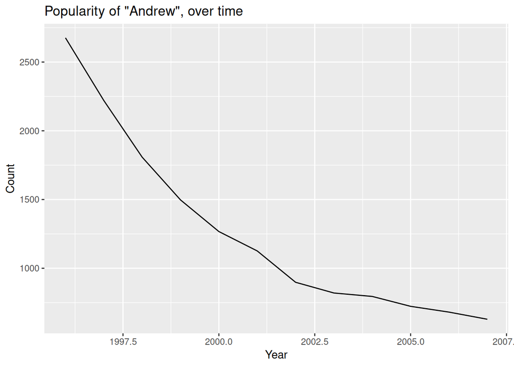

```r
## How has the popularity of the name "ANDREW" changed over time?
andrew <- filter(boysNames, Name == "ANDREW")

ggplot(andrew, aes(x = Year, y = Count)) +
    geom_line() +
    ggtitle("Popularity of \"Andrew\", over time")
```

# Additional reading and resources

- Learn from the best: http://adv-r.had.co.nz/; http://r4ds.had.co.nz/
- R documentation: http://cran.r-project.org/manuals.html
- Collection of R tutorials: http://cran.r-project.org/other-docs.html
- R for Programmers (by Norman Matloff, UC–Davis)

http://heather.cs.ucdavis.edu/~matloff/R/RProg.pdf

- Calling C and Fortran from R (by Charles Geyer, UMinn)

http://www.stat.umn.edu/~charlie/rc/

- State of the Art in Parallel Computing with R (Schmidberger et al.)

http://www.jstatso|.org/v31/i01/paper

- Institute for Quantitative Social Science: http://iq.harvard.edu
- IQSS Data Science Services: http://dss.iq.harvard.edu/